# Plotting Super Mario in R Using `ggplot2`

An Exercise on Data Tidying Text

Joseph S. Tabadero, Jr.

2017-09-30

# Introduction

One student from Philippine Science High School-Cordillera Administrative Region Campus shared a drawing of Super Mario plotted using Cartesian Coordinates by hand. The drawing comes with hand-written note containing coordinates of the shapes that comprise the Super Mario drawing. I wanted to try plotting the points manually at first but I could not read some of the coordinates in the hand-written note. Doing a bit of searching in the web, I found this [PDF](https://gsclchood.wikispaces.com/file/view/Mario.pdf/423175626/Mario.pdf) containing the coordinates for the corresponding body parts (shapes) of Super Mario. The PDF turns out to be a worksheet for a plotting work.

As background, the student’s math class will soon have an assessment about the Cartesian Coordinate system and the topic includes plotting points and lines.

Now, the list of coordinates is long. And I am lazy at plotting points manually. So I thought, if I can only parse the coordinates and store them as a tidy data set, I can easily plot Mario using `ggplot2`.

In order to plot Mario in R using `ggplot2`, we need to do the following:

- Make a tidy data set from the coordinates provided in the PDF. This means that every row should contain a unique pair of $x$ and $y$ coordinates, and there should be separate columns for each of the $x$ and $y$ coordinates.
- Use `ggplot2` to connect the points according to the shape that they are grouped in.

# Tidying the data

**Tidy data** is the foundation of a `ggplot2` graphic. To know more about tidy data, read [this](https://www.jstatsoft.org/article/view/v059i10/v59i10.pdf) by Hadley Wickham published in the Journal of Stistical Software.

We can actually parse the required information directly from the PDF in R, but I think the old trick of copying and pasting will do. I have copied and pasted the relevant information from the PDF and saved it in the file [`mario.txt`](https://raw.githubusercontent.com/josephuses/Plotting-Super-Mario-in-R/master/mario.txt) that you can download [here](https://raw.githubusercontent.com/josephuses/Plotting-Super-Mario-in-R/master/mario.txt). Again, since I am a lazy person, I did not do any more tidying beyond that. Everything else will be done in R.

We shall now import the text file into R.

```r
library(tidyverse)
mario <- "mario.txt"
mario <- readChar(mario, file.info(mario)$size)
head(mario)
```

```
## [1] "# Shape 01\n(-11,4.5) , (-10.5,5.5) , (-9,4.5) , (-10,3.5)\n# Shape 02\n(-9,4.5) , (-8.5,3.5) , (-8,2) , (-7.5,1) , (-8.5,.5) , (-9,1) , (-10,2) , (-11,3.5) , (-11.5,5) , (-11,6) , (-10,6.5) , (-9.5,6.5) , (-9,6) , (-8.5,5) , (-8.5,3.5)\n# Shape 03\n(-8,2) , (-7.5,2.5) , (-7,3.5) , (-6.5,5) …
```

At this point, we have a very messy data. We can see that each shape grouping is indicated by `#` symbol, the word `Shape`, and a two-digit, numeric identifier. Also, every new line is indicated as `\n`. We shall remove `\n` from `mario` first.

```r
mario <- str_replace_all(mario, "\n", "")
```

We shall now remove the pattern `# Shape no` from `mario` and store the data as a vector of coordinates. Here, `[:blank:]` is a literal for a blank space, `[:alnum:]` is a literal for an alphanumeric character. `[^[:alnum:]]` is *not* an alphanumeric character.

```r
mario <-  str_split(mario, "[^[:alnum:]][:blank:]Shape[:blank:][:alnum:][:alnum:]", simplify = TRUE)
head(t(mario))
```

```
##      [,1]
## [1,] ""
## [2,] "(-11,4.5) , (-10.5,5.5) , (-9,4.5) , (-10,3.5)"
## [3,] "(-9,4.5) , (-8.5,3.5) , (-8,2) , (-7.5,1) , (-8.5,.5) , (-9,1) , (-10,2) , (-11,3.5) , (-11.5,5) , (-11,6) , (-10,6.5) , (-9.5,6.5) , (-9,6) , (-8.5,5) , (-8.5,3.5)"
## [4,] "(-8,2) , (-7.5,2.5) , (-7,3.5) , (-6.5,5) , (-7.5,7) , (-8,7) , (-9.5,6.5) , (-9.5,7) , (-11,9.5) , (-11,11.5) , (-10,13) , (-8,15) , (-5.5,17) , (-3.5,18) , (-1,19) , (1,19) , (4,17.5) , (6,15.5) , (7,14) , (7.5,12) , (7.5,10) , (6.5,9.5) , (5,10.5) , (3.5,11) , (-1.5,11) , (-4,10) , (-8,7…
## [5,] "(-1.5,11) , (-2.5,12) , (-2.5,13.5) , (-2,14.5) , (-1,15) , (0,15.5) , (2,15.5) , (3.5,15) , (4,14) , (4,13) , (3.5,12) , (3.5,11)"
## [6,] "(-.5,11.5) , (-1.5,12) , (0,15) , (1,14) , (1.5,15) , (3.5,12.5) , (2.5,11.5) , (1.5,13.5) , (1,12.5) , (0,13.5) , (-.5,11.5)"
```

As we can now see, the points are now somewhat indexed according to the shape where they belong. We shall now make use of this fact and convert `mario` into a `data.frame` object.

```r
mario <- data.frame(coords = t(mario))
head(mario)
```

```
##                                                                                                                                                                                                                                                                                                          …
## 1
## 2                                                                                                                                                                                                                                                                  (-11,4.5) , (-10.5,5.5) , (-9,4.5) , (…
## 3                                                                                                                                            (-9,4.5) , (-8.5,3.5) , (-8,2) , (-7.5,1) , (-8.5,.5) , (-9,1) , (-10,2) , (-11,3.5) , (-11.5,5) , (-11,6) , (-10,6.5) , (-9.5,6.5) , (-9,6) , (-8.5,5) , (-…
## 4 (-8,2) , (-7.5,2.5) , (-7,3.5) , (-6.5,5) , (-7.5,7) , (-8,7) , (-9.5,6.5) , (-9.5,7) , (-11,9.5) , (-11,11.5) , (-10,13) , (-8,15) , (-5.5,17) , (-3.5,18) , (-1,19) , (1,19) , (4,17.5) , (6,15.5) , (7,14) , (7.5,12) , (7.5,10) , (6.5,9.5) , (5,10.5) , (3.5,11) , (-1.5,11) , (-4,10) , (-8,7.5) …
## 5                                                                                                                                                                              (-1.5,11) , (-2.5,12) , (-2.5,13.5) , (-2,14.5) , (-1,15) , (0,15.5) , (2,15.5) , (3.5,15) , (4,14) , (4,13) , (3.5,12) , …
## 6                                                                                                                                                                                   (-.5,11.5) , (-1.5,12) , (0,15) , (1,14) , (1.5,15) , (3.5,12.5) , (2.5,11.5) , (1.5,13.5) , (1,12.5) , (0,13.5) , (-…
```

We have created a variable `coords` in the `mario` data frame that contains the coordinates. Each row now contains all of the coordinates that corresponded to the same shape. Unfortunately, R cannot yet use this for plotting since the data is not yet *tidy*. Before we do anything else, let us create the `shape` variable that will contain the shape group identifier for each row.

```r
mario <- mario %>% mutate(shape = rownames(mario))
head(mario,2)
```

```
##                                           coords shape
## 1                                                    1
## 2 (-11,4.5) , (-10.5,5.5) , (-9,4.5) , (-10,3.5)     2
```

```r
nrow(mario)
```

```
## [1] 40
```

We can see that the first row contains no coordinates. We shall fix this soon enough. We shall also split the coordinates separated by a blank space, a comma, and another blank space, and store the separated coordinates as new rows, but still retaining the shape ID of each pair of coordinates.

```r
mario <- mario %>%
  mutate(coords = strsplit(as.character(coords), " , ")) %>%
  unnest(coords)
head(mario, 10)
```

```
##    shape      coords
## 1      2   (-11,4.5)
## 2      2 (-10.5,5.5)
## 3      2    (-9,4.5)
## 4      2   (-10,3.5)
## 5      3    (-9,4.5)
## 6      3  (-8.5,3.5)
## 7      3      (-8,2)
## 8      3    (-7.5,1)
## 9      3   (-8.5,.5)
## 10     3      (-9,1)
```

```r
nrow(mario)
```

```
## [1] 365
```

```r
mario <- mario %>% mutate(shape = as.integer(shape) - 1)
head(mario,10)
```

```
##    shape      coords
## 1      1   (-11,4.5)
## 2      1 (-10.5,5.5)
## 3      1    (-9,4.5)
## 4      1   (-10,3.5)
## 5      2    (-9,4.5)
## 6      2  (-8.5,3.5)
## 7      2      (-8,2)
## 8      2    (-7.5,1)
## 9      2   (-8.5,.5)
## 10     2      (-9,1)
```

```r
nrow(mario)
```

```
## [1] 365
```

We are slowly getting there. But R does not recognize `coords` yet as a pair of $x$ and $y$ coordinates. We need to separate them into different columns.

```r
mario <- separate(mario, coords, sep = ",", into = c("x","y"))
head(mario)
```

```
##   shape      x    y
## 1     1   (-11 4.5)
## 2     1 (-10.5 5.5)
## 3     1    (-9 4.5)
## 4     1   (-10 3.5)
## 5     2    (-9 4.5)
## 6     2  (-8.5 3.5)
```

Some final steps have to be undertaken. We need to remove the parentheses from the coordinates, and then tell R that $x$ and $y$ are `numeric` and not `characters`.

```r
mario <- mario %>%
  mutate(
    # delete the first occurrence of a non-alphanumeric character
    x = as.numeric(str_replace(x,"[^[:alnum:]]", "")),
    # delete the last occurrence of a non-alphanumeric character
    y = as.numeric(str_replace(y,"[^[:alnum:]]$", ""))
  )
head(mario)
```

```
##   shape     x   y
## 1     1 -11.0 4.5
## 2     1 -10.5 5.5
## 3     1  -9.0 4.5
## 4     1 -10.0 3.5
## 5     2  -9.0 4.5
## 6     2  -8.5 3.5
```

Looking at the data `mario`, we can now see that each occurrence of a pair of points belong to only one row, and that each column contains only one variable. Our data is now tidy! We have stored the tidied data set in the file `mario_tidy.txt`. You can also download that [here](https://github.com/josephuses/Plotting-Super-Mario-in-R).

# Plotting the coordinates

## Where are the points located?

We can easily plot the points by using `geom_point` in `ggplot2`.

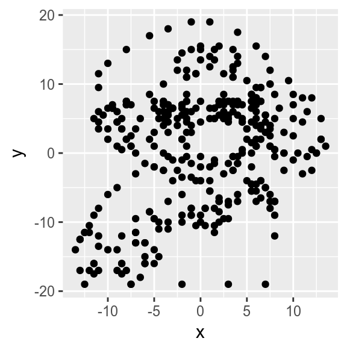

Plotting dots to connect

```r
ggplot(mario, aes(x, y)) +
  geom_point()
```

## Connecting the dots

Hey! I think we can already distinguish Super Mario with just the points! But how do we connect the points (dots) sequentially? Well, good for us, `geom_path` does just that! However, we want to connect only the points that belong to a unique shape identifier. That is easily done with the `group` aesthetic in `geom_path`.

[figure not shown]

Connecting the dots

```r
ggplot(mario, aes(x, y)) +
  geom_point() +
  geom_path(aes(group=shape))
```

## Removing the dots

We can clean the figure by removing the points.

[figure not shown]

Cleaning the guides

```r
ggplot(mario, aes(x, y)) +
  geom_path(aes(group=shape))
```

I prefer a clean background for Super Mario.

[figure not shown]

```r
ggplot(mario, aes(x, y)) +
  geom_path(aes(group=shape)) +
  theme_bw()
```

## Some work to be done

And that is it! Some work should be done if you want to add some colors to this plot. Ggplot2’s `geom_polygon` is up to such a task. We only need to specify the color for each identifier. In fact we need to specify some more groupings of coordinates in order for this to work as you can see in the image below.

[figure not shown]

Technicolor Mario

```r
ggplot(mario, aes(x, y)) +
  geom_polygon(aes(group=shape,fill=as.factor(shape))) +
  theme_bw() +
  geom_path(aes(group=shape)) +
  theme(
    legend.position = "none"
  )
```